# R 연산자

Jang, Eunhee

2018년 5월 9일

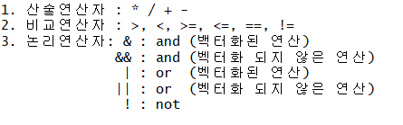

## 벡터화된 연산 vs 백터화되지 않은 연산

예1: x <- c(1,2,3) x > c (1,1,1) & x < c(3,3,3) # combine을 이용하여 벡터화 시킴

예2: x <- 1 x > -2 && x < 2 # 벡터화되지 않은 연산

### 기타 비교 연산자

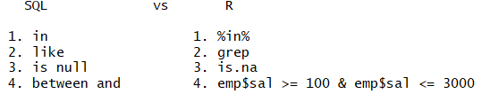

기타 비교 연산자( SQL vs R )

#### 문제9. 직업이 SALESMAN이 아닌 사원들의 이름과 월급과 직업을 출력하시오

```r
emp <- read.csv("C:/data/emp.csv", header = T)
attach(emp)

emp[emp$job != 'SALESMAN' , c("ename", "sal", "job")]
```

```
##     ename  sal       job
## 1   SMITH  800     CLERK
## 4   JONES 2975   MANAGER
## 6   BLAKE 2850   MANAGER
## 7   CLARK 2450   MANAGER
## 8   SCOTT 3000   ANALYST
## 9    KING 5000 PRESIDENT
## 11  ADAMS 1100     CLERK
## 12  JAMES  950     CLERK
## 13   FORD 3000   ANALYST
## 14 MILLER 1300     CLERK
## 15   JACK 3200     CLERK
```

##### 문제10. 1981년 12월 03일에 입사한 사원들의 이름과 입사일을 출력하시오

```r
emp[emp$hiredate == '1981-12-03', c("ename","hiredate")]
```

```
##    ename   hiredate
## 12 JAMES 1981-12-03
## 13  FORD 1981-12-03
```

#### 문제11. 직업이 SALESMAN이고 월급이 1000이상인 사원들의 이름과 월급과 직업을 출력하시오

```r
emp[emp$job == 'SALESMAN' & emp$sal >= 1000, c("ename", "sal", "job")]
```

```
##     ename  sal      job
## 2   ALLEN 1600 SALESMAN
## 3    WARD 1250 SALESMAN
## 5  MARTIN 1250 SALESMAN
## 10 TURNER 1500 SALESMAN
```

#### 문제12. 직업이 SALESMAN, ANALYST 인 사원들의 이름과 직업을 출력하시오

```r
# emp[emp$job == 'SALESMAN' | emp$job == 'ANALYST', c("ename","job")]
emp[emp$job %in% c("SALESMAN", "ANALYST"), c("ename","job")]
```

```
##     ename      job
## 2   ALLEN SALESMAN
## 3    WARD SALESMAN
## 5  MARTIN SALESMAN
## 8   SCOTT  ANALYST
## 10 TURNER SALESMAN
## 13   FORD  ANALYST
```

#### 문제13. 직업이 SALESMAN, ANALYST 이 아니 사원들의 이름과 직업을 출력하시오닌

```r
#emp[emp$job != 'SALESMAN' & emp$job != 'ANALYST', c("ename","job")]
emp[!emp$job %in% c("SALESMAN", "ANALYST"), c("ename","job")]
```

```
##     ename       job
## 1   SMITH     CLERK
## 4   JONES   MANAGER
## 6   BLAKE   MANAGER
## 7   CLARK   MANAGER
## 9    KING PRESIDENT
## 11  ADAMS     CLERK
## 12  JAMES     CLERK
## 14 MILLER     CLERK
## 15   JACK     CLERK
```

#### 문제14. 커미션이 null인 사원들의 이름과 월급과 커미션을 출력하시오

```r
emp[is.na(emp$comm), c("ename", "sal", "comm")]
```

```
##     ename  sal comm
## 1   SMITH  800   NA
## 4   JONES 2975   NA
## 6   BLAKE 2850   NA
## 7   CLARK 2450   NA
## 8   SCOTT 3000   NA
## 9    KING 5000   NA
## 11  ADAMS 1100   NA
## 12  JAMES  950   NA
## 13   FORD 3000   NA
## 14 MILLER 1300   NA
## 15   JACK 3200   NA
```

### r 에서의 null값

1. NULL (아무것도 없다) -> is.null() 2. NA (결손값) -> is.na() // Not Avalible 3. NanN (비수치) -> is.nan() // Not a Number

### null (아무것도 없다) 활용할 때

```r
 x <- NULL
 for (i in 1:10)
    x <- append(x, i*i)
  x
```

```
##  [1]   1   4   9  16  25  36  49  64  81 100
```

```r
# 반복문으로 처리할 오브젝트의 초기값을 null로 설정할 때 활용한다.
```

#### 문제15.월급이 1000에서 3000 사이인 사원들의 이름과 월급을 출력하시오

```r
emp[emp$sal >= 1000 & emp$sal <= 3000, c("ename", "sal")]
```

```
##     ename  sal
## 2   ALLEN 1600
## 3    WARD 1250
## 4   JONES 2975
## 5  MARTIN 1250
## 6   BLAKE 2850
## 7   CLARK 2450
## 8   SCOTT 3000
## 10 TURNER 1500
## 11  ADAMS 1100
## 13   FORD 3000
## 14 MILLER 1300
```

```r
# emp$sal >= 1000 is vector
```

#### 문제16. 이름의 첫글자가 A로 시작하는 사원들의 이름과 월급을 출력하시오

```r
emp[grep("^A",emp$ename), c("ename", "sal")]
```

```
##    ename  sal
## 2  ALLEN 1600
## 11 ADAMS 1100
```

```r
# ^ : 첫번째
# $ : 마지막
# . : 한자리
# * : wild card
```

#### 문제17. 이름의 끝글자가 T로 끝나는 사원들의 이름과 월급을 출력하시오

```r
emp[grep("T$", emp$ename), c("ename", "sal")]
```

```
##   ename  sal
## 8 SCOTT 3000
```

#### 문제18. 이름의 두번째 철자가 M인 사원들의 사원들의 이름과 월급을 출력하시오

```r
emp[grep("^.M", emp$ename), c("ename", "sal")]
```

```
##   ename sal
## 1 SMITH 800
```

### 중복제거

#### 문제19. 부서번호를 출력하는데 중복 제거해서 출력하시오  
install.packages(“data.table”)

```r
library(data.table)

data.table("부서번호" = unique(emp$deptno))
```

```
##    부서번호
## 1:       20
## 2:       30
## 3:       10
## 4:       70
```

```r
# data.table("컬럼별칭" = 컬럼)
```

#### 문제20. 직업을 출력하는데 중복을 제거해서 출력하시오

```r
data.table("직업" = unique(emp$job))
```

```
##         직업
## 1:     CLERK
## 2:  SALESMAN
## 3:   MANAGER
## 4:   ANALYST
## 5: PRESIDENT
```

## 정렬 작업

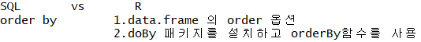

orderby

#### 문제21. 이름과 월급을 출력하는데 월급이 높은 사원부터 출력하시오

```r
emp[order(emp$sal, decreasing = T), c("ename", "sal")]
```

```
##     ename  sal
## 9    KING 5000
## 15   JACK 3200
## 8   SCOTT 3000
## 13   FORD 3000
## 4   JONES 2975
## 6   BLAKE 2850
## 7   CLARK 2450
## 2   ALLEN 1600
## 10 TURNER 1500
## 14 MILLER 1300
## 3    WARD 1250
## 5  MARTIN 1250
## 11  ADAMS 1100
## 12  JAMES  950
## 1   SMITH  800
```

#### 문제22. 이름과 입사일을 출력하는데 먼저 입사한 사원부터 출력하시오

```r
emp[order(emp$hiredate, decreasing = F), c("ename", "hiredate")]
```

```
##     ename   hiredate
## 1   SMITH 1980-12-17
## 2   ALLEN 1981-02-20
## 3    WARD 1981-02-22
## 4   JONES 1981-04-02
## 6   BLAKE 1981-05-01
## 7   CLARK 1981-06-09
## 10 TURNER 1981-09-08
## 5  MARTIN 1981-09-28
## 9    KING 1981-11-17
## 12  JAMES 1981-12-03
## 13   FORD 1981-12-03
## 14 MILLER 1982-01-23
## 15   JACK 1982-01-23
## 8   SCOTT 1987-04-19
## 11  ADAMS 1987-05-23
```

#### 문제23.직업이 SALESMAN인 사원들의 이름과 월급을 출력하는데 월급이 높은 사원부터 출력하시오

```r
# emp[emp$job == 'SALESMAN' & order(emp$sal, decreasing = T), c("ename", "sal")]
# order by 제대로 안됨.

x<- emp[emp$job == 'SALESMAN' , c("ename", "sal")]
# str(x): x is 'data.frame'

x[order(x$sal, decreasing = T), c("ename","sal")]
```

```
##     ename  sal
## 2   ALLEN 1600
## 10 TURNER 1500
## 3    WARD 1250
## 5  MARTIN 1250
```

```r
# 변수활용하기
# oracle 실행순서와 같다.
```

### x라는 변수를 지우고 싶다면?

```r
# 변수의 존재 확인
ls()
```

```
## [1] "emp" "i"   "x"
```

```r
# 변수 지우기
rm(x)
```

#### 문제24. (점심시간 문제) 직업이 ANALYST가 아닌 사원들의 이름과 월급과 직업을 출력하는데 월급이 높은 사원부터 출력하시오

```r
# emp[emp$job != 'ANALYST' & order(emp$sal, decreasing = T), c("ename", "sal", "job")]

x <- emp[emp$job != 'ANALYST', c("ename", "sal", "job")]
x[order(x$sal, decreasing = T), c("ename", "sal", "job")]
```

```
##     ename  sal       job
## 9    KING 5000 PRESIDENT
## 15   JACK 3200     CLERK
## 4   JONES 2975   MANAGER
## 6   BLAKE 2850   MANAGER
## 7   CLARK 2450   MANAGER
## 2   ALLEN 1600  SALESMAN
## 10 TURNER 1500  SALESMAN
## 14 MILLER 1300     CLERK
## 3    WARD 1250  SALESMAN
## 5  MARTIN 1250  SALESMAN
## 11  ADAMS 1100     CLERK
## 12  JAMES  950     CLERK
## 1   SMITH  800     CLERK
```

#### 문제25. 문제 24번을 doBy를 이용하여 실행하시오

```r
# install.packages("doBy")
```

```r
library("doBy")

orderBy(~-sal, emp[emp$job != 'ANALYST', c("ename", "sal", "job")])
```

```
##     ename  sal       job
## 9    KING 5000 PRESIDENT
## 15   JACK 3200     CLERK
## 4   JONES 2975   MANAGER
## 6   BLAKE 2850   MANAGER
## 7   CLARK 2450   MANAGER
## 2   ALLEN 1600  SALESMAN
## 10 TURNER 1500  SALESMAN
## 14 MILLER 1300     CLERK
## 3    WARD 1250  SALESMAN
## 5  MARTIN 1250  SALESMAN
## 11  ADAMS 1100     CLERK
## 12  JAMES  950     CLERK
## 1   SMITH  800     CLERK
```

```r
# - option이 붙으면 높은 것부터, 없으면 낮은 것부터
```

#### 문제26. crime_loc.csv를 내려받고 R로 로드한 후에 살인이 일어나는 장소와 건수를 출력하는데 살인이 일어나는 건수가 높은것부터 출력하시오

```r
crime_loc <- read.csv("C:/data/crime_loc.csv", header = T)
attach(crime_loc)

#str(crime_loc)
# head(crime_loc, 10)
# 위에 10개만 보겠다.


library("doBy")

head(orderBy(~-건수, crime_loc[crime_loc$범죄 == '살인', c("장소", "건수")]), 10)
```

```
##         장소 건수
## 83        집  312
## 85      노상  280
## 82    아파트  242
## 108     기타  131
## 89      병원   87
## 88  숙박업소   43
## 90    사무실   40
## 86      상점   23
## 101 의료기관   19
## 91      공장   15
```